# Correlations between EWS and effective reproduction number

2019-01-22

To complement the fixed window analysis focused on emergence and elimination events, we also want to show that the dynamics of EWS reflect those of $R_E$. I estimated $R_E$ over the observations via particle filtering and state estimation. Here, I read in those values for each city and correlate them with top-performing EWS. Top-performing EWS are those with high AUC in the emergence and elimination scenarios. Note that $R_E$ was calculated as:

$$R_E = \frac{\beta_t}{\gamma} \frac{S_t}{N_t}.$$

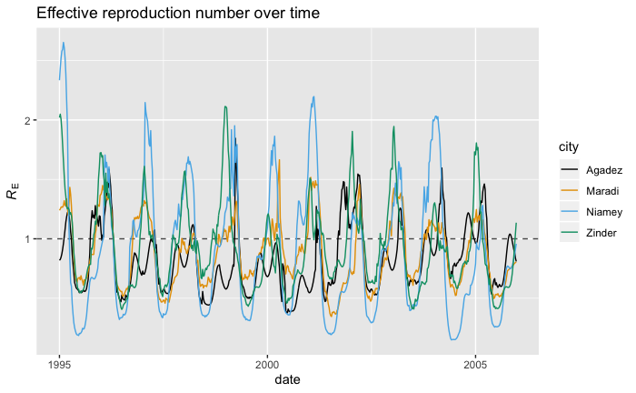

```r
library(tidyverse)
cities <- c("Agadez", "Maradi", "Niamey", "Zinder")  # the four city names
reffs <- tibble()  # empty tibble for storage
for(do_city in cities){
  fname <- paste0("../../results/filtered-states-", do_city, ".RDS")
  raw_filter <- readRDS(fname)
  reff_id <- which(raw_filter$state == "effective_r_seasonal")
  tmp_reff <- raw_filter$data[[reff_id]] %>%
    dplyr::select(time, med, week, date) %>%
    dplyr::mutate(city = do_city)

  reffs <- bind_rows(reffs, tmp_reff)
}
ggplot(reffs, aes(x = date, y = med, color = city)) +
  geom_hline(aes(yintercept = 1), linetype = 2, color = "grey35") +
  geom_line() +
  labs(x = "date", y = expression(italic(R)[E]),
       title = "Effective reproduction number over time") +
  ggthemes::scale_color_colorblind()
```

```r
library(spaero)
fname <- "../../data/clean-data/weekly-measles-incidence-niger-cities-clean.RDS"
measles_data <- readRDS(fname) %>%
  filter(year > 1994)  # drop first NA year, only used for modeling
all_stats <- tibble()  # empty tibble for storage
for(do_region in unique(measles_data$region)){

  cases <- measles_data %>%
    filter(region == do_region) %>%
    pull(cases)

  city_stats <- spaero::get_stats(
    x = cases,
    center_trend = "local_constant",
    center_kernel = "uniform",
    center_bandwidth = 16,
    stat_trend = "local_constant",
    stat_kernel = "uniform",
    stat_bandwidth = 16,
    lag = 1,
    backward_only = TRUE
  )$stats

  city_stats_tb <- as_tibble(city_stats) %>%
    mutate(
      time_iter = 1:n(),
      date = unique(measles_data$date)
    ) %>%
    gather(key = ews, value = value, -time_iter, -date) %>%
    mutate(region = do_region)

  all_stats <- bind_rows(all_stats, city_stats_tb)
}
best_ews <- c("autocorrelation", "autocovariance", "mean", "variance")
all_stats <- all_stats %>%
  dplyr::filter(ews %in% best_ews)
```

Now I look at scatterplots of $R_E$ versus EWS.

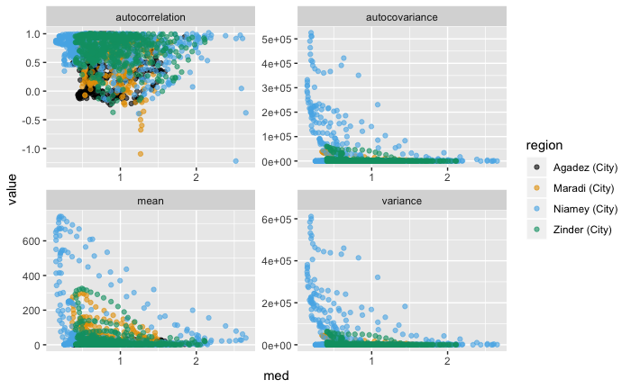

```r
reffs <- reffs %>%
  dplyr::mutate(region = paste0(city, " (City)")) %>%
  dplyr::select(-city)
ews_reffs <- left_join(all_stats, reffs)
ggplot(ews_reffs, aes(x = med, y = value, color = region)) +
  geom_point(alpha = 0.6) +
  facet_wrap(~ews, scales = "free") +
  ggthemes::scale_color_colorblind()
```

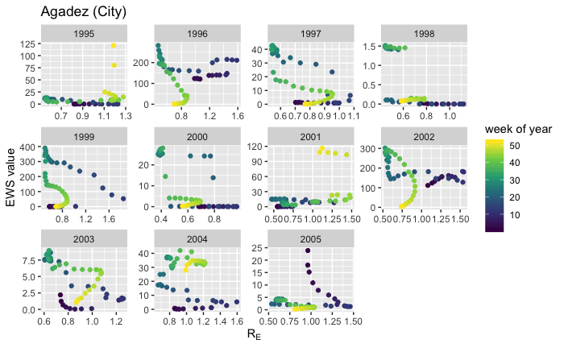

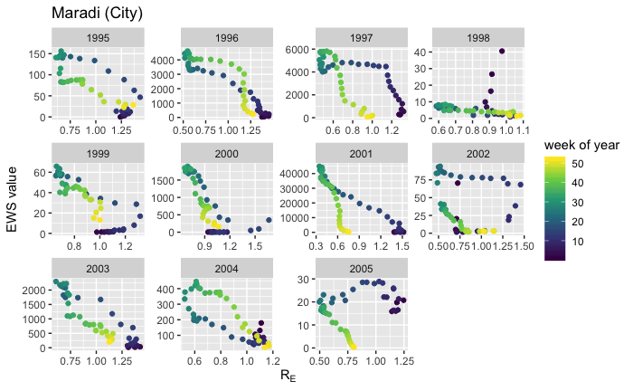

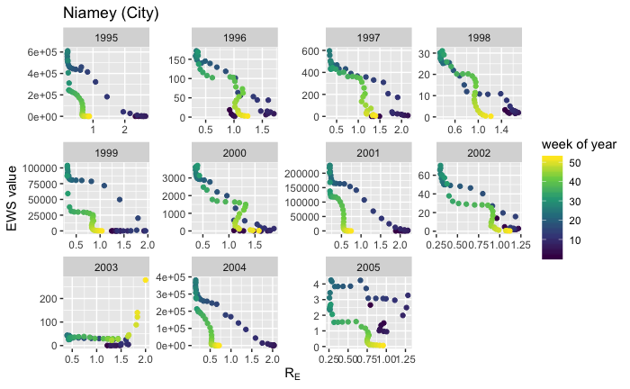

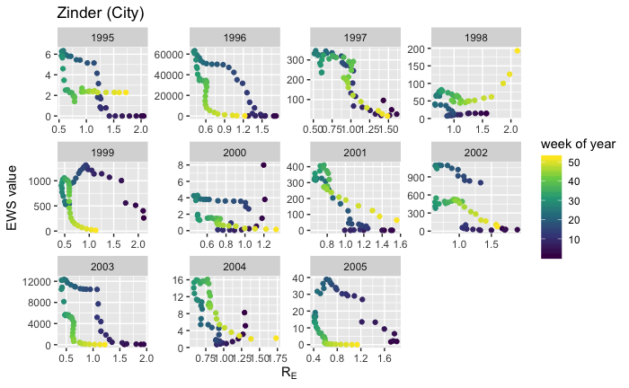

```r
for(do_region in unique(ews_reffs$region)){
  print(ggplot(filter(ews_reffs, region == do_region & ews == "variance"),
       aes(x = med, y = value, color = lubridate::week(date))) +
    geom_point() +
    facet_wrap(~lubridate::year(date), scales = "free") +
    labs(x = expression(R[E]), y = "EWS value", title = do_region) +
    scale_color_viridis_c(name = "week of year", direction = 1))
}
```

So those plots are pretty weird because of the temporal cycling. What if I remove the seasonal component via differencing?

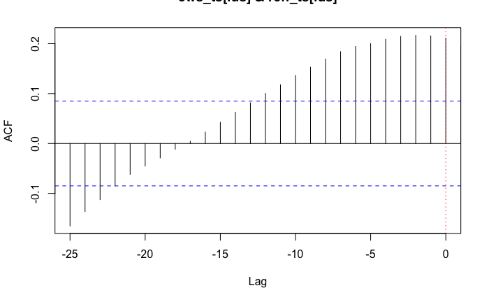

```r
test <- filter(ews_reffs, region == "Agadez (City)" & ews == "variance") %>%
  dplyr::mutate(value = dplyr::lag(value, n = 20))
test_reff <- test$med
test_ews <- log(test$value)
reff_ts <- ts(test_reff, frequency = 52)
ews_ts <- ts(test_ews, frequency = 52)
ews_ts[abs(ews_ts)==Inf] <- NA
ids <- which(!is.na(ews_ts))
ccf(ews_ts[ids], reff_ts[ids], type = "correlation", lag.max = 25, xlim = c(-25, 0))
abline(v = 0, col = "red", lty = 3)
```

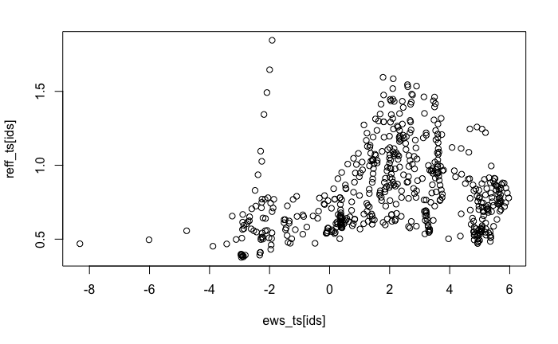

```r
plot(ews_ts[ids], reff_ts[ids])
```

```r
# plot(test_reff, test_ews)
# cor.test(test_reff, test_ews, method = "spearman", use = "pairwise.complete.obs")
#
# par(mfrow = c(2,1))
# plot(test_reff, type = "l")
# plot(test_ews, type = "l")
```

# Rolling correlation?

The region-specific plots of $R_E$ and variance over time make it look like they are correlated at some points and not correlated at others. Wonder if a rolling correlation can do the trick?

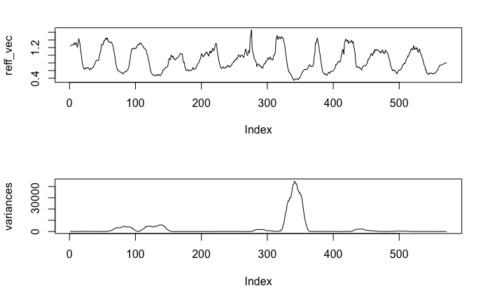

```r
do_region <- "Maradi (City)"
variances <- ews_reffs %>%
  filter(ews == "variance" & region == do_region) %>%
  pull(value)
reff_vec <- ews_reffs %>%
  filter(ews == "variance" & region == do_region) %>%
  pull(med)
cases <- measles_data %>%
    filter(region == do_region) %>%
    pull(cases)
par(mfrow = c(2, 1))
plot(reff_vec, type = "l")
plot(variances, type = "l")
```

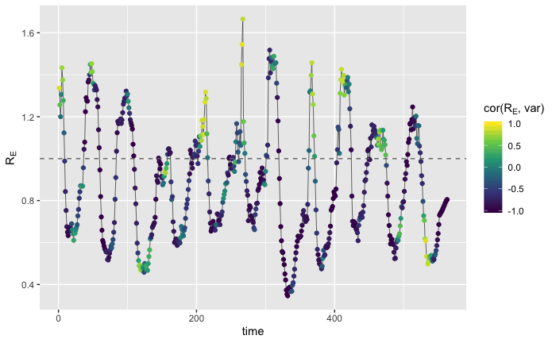

```r
test <- zoo::rollapply(data.frame(variances, reff_vec), 10, function(x) cor(x[,1],x[,2]), by.column=FALSE)
df <- tibble(x = test, y = reff_vec[10:length(reff_vec)])
ggplot(df, aes(x = seq_along(x), y = y, color = x)) +
  geom_line(color = "grey35", size = 0.3) +
  geom_point() +
  geom_hline(aes(yintercept = 1), linetype = 2, color = "grey45") +
  scale_color_viridis_c(limits = c(-1,1), name = expression(paste("cor(", R[E], ", var)"))) +
  labs(x = "time", y = expression(R[E]))
```

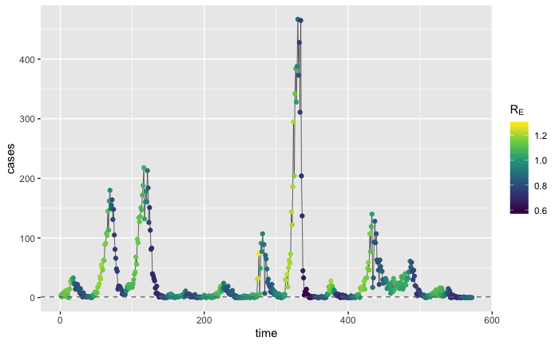

```r
# df <- tibble(x = variances[10:length(reffs)], y = reffs[10:length(reffs)])
# ggplot(df, aes(x = seq_along(x), y = y, color = sqrt(x))) +
#   geom_line(color = "grey35", size = 0.3) +
#   geom_point() +
#   geom_hline(aes(yintercept = 1), linetype = 2, color = "grey45") +
#   scale_color_viridis_c(name = "variance") +
#   labs(x = "time", y = expression(R[E]))
#
df <- tibble(x = reff_vec, y = cases)
ggplot(df, aes(x = seq_along(x), y = y, color = sqrt(x))) +
  geom_line(color = "grey35", size = 0.3) +
  geom_point() +
  geom_hline(aes(yintercept = 1), linetype = 2, color = "grey45") +
  scale_color_viridis_c(name = expression(R[E])) +
  labs(x = "time", y = "cases")
```

```r
max_reffs <- ews_reffs %>%
  group_by(ews, region, lubridate::year(date)) %>%
  filter(med == max(med))
max_reffs <- ews_reffs %>%
  mutate(year = lubridate::year(date)) %>%
  group_by(year, ews, region) %>%
  dplyr::mutate(
    high_reff = ifelse(med > 1, TRUE, FALSE),
    value = ifelse(ews != "autocorrelation", log(value), value)
  )
```

[output not shown]

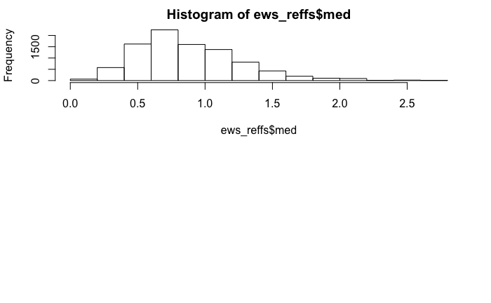

```r
hist(ews_reffs$med)
```

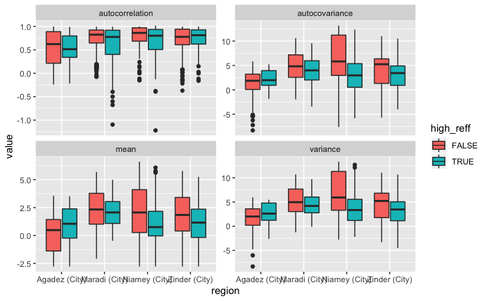

```r
ggplot(max_reffs, aes(x = region, y = value, fill = high_reff)) +
  geom_boxplot() +
  facet_wrap(~ews, scales = "free_y")
```